# How Often Does Global Correlation Disagree With Cohort Majority?

Amir (Building on Kevin R. Coombes’ framework)

Original: 2026-01-04; Latest Run: 2026-01-04

# Summary

We estimate how often the **global** correlation disagrees with the **majority** of cohort-specific correlations, using a manageable subset of genes and miRs (top 1000 variable genes × top 50 variable miRs). In this subset, **31.4%** of valid pairs show sign reversal; among pairs with |global r| ≥ 0.20 the reversal rate is **16.5%**. This provides a main-text quantitative headline for Simpson-style effects.

# Background

Kevin’s manuscript emphasizes context dependence. A clean quantitative summary is: “How often does the global correlation disagree with the majority of cohorts?”** Computing this for the full 23M pairs is expensive, so we estimate it on a high-variance subset that should be enriched for meaningful signals.

# Data and Setup

Rationale: load matched data and select high-variance subsets for efficient computation.

```r
source("00-paths.R")
f1 <- file.path(paths$mirtcga, "matchedNoGBM.Rda")
f2 <- file.path(paths$mirtcga, "matchedNoGBM.rda")
if (file.exists(f1)) {
  load(f1)
} else if (file.exists(f2)) {
  load(f2)
} else {
  stop("Cannot find matchedNoGBM.Rda or matchedNoGBM.rda in ", paths$mirtcga)
}
rm(paths)
```

We will use a subset of genes and miRs with high variance to reduce compute time while retaining strong signals.

Rationale: select top variable genes and miRs.

```r
G <- 1000
M <- 50

geneVar <- apply(mRNAdata, 1, var)
mirVar <- apply(miRdata, 1, var)

topGenes <- names(sort(geneVar, decreasing = TRUE))[1:G]
topMirs <- names(sort(mirVar, decreasing = TRUE))[1:M]

length(topGenes)
```

```
## [1] 1000
```

```r
length(topMirs)
```

```
## [1] 50
```

With this subset, we can compute global and within-cohort correlations efficiently.

# Global Correlation (Subset)

Rationale: compute global correlations using matrix multiplication.

```r
mRNA_sub <- mRNAdata[topGenes, ]
miR_sub <- miRdata[topMirs, ]

scaledMir <- scale(t(miR_sub))/(ncol(miR_sub) - 1)
stdRNA <- t(scale(t(mRNA_sub)))

coco <- stdRNA %*% scaledMir
dim(coco)
```

```
## [1] 1000   50
```

We now compute within-cohort correlations across the same subset.

# Within-Cohort Correlations (Subset)

Rationale: compute per-cohort correlation matrices for the subset.

```r
cohorts <- levels(cancerType)
cococt <- array(NA, dim = c(G, M, length(cohorts)),
                dimnames = list(topGenes, topMirs, cohorts))

for (ct in cohorts) {
  idx <- which(cancerType == ct)
  if (length(idx) < 10) next
  mymirs <- miR_sub[, idx, drop = FALSE]
  mymrna <- mRNA_sub[, idx, drop = FALSE]
  if (ncol(mymirs) < 3) next

  scaledMir_ct <- scale(t(mymirs))/(ncol(mymirs) - 1)
  stdRNA_ct <- t(scale(t(mymrna)))
  cococt[, , ct] <- stdRNA_ct %*% scaledMir_ct
}
```

Next we compute the reversal rate: global sign vs majority cohort sign.

# Reversal Rate

Rationale: define majority sign per pair and compare to global sign.

```r
minCohorts <- 10
minGlobalAbs <- 0.20

nValid <- apply(cococt, 1:2, function(x) sum(!is.na(x)))
nPos <- apply(cococt, 1:2, function(x) sum(x > 0, na.rm = TRUE))
nNeg <- apply(cococt, 1:2, function(x) sum(x < 0, na.rm = TRUE))

globalSign <- sign(coco)
majoritySign <- ifelse(nPos > nNeg, 1, ifelse(nNeg > nPos, -1, 0))

valid <- nValid >= minCohorts & majoritySign != 0
reversal <- valid & (globalSign != 0) & (globalSign != majoritySign)

overallRate <- mean(reversal[valid], na.rm = TRUE)
strongRate <- mean(reversal[valid & abs(coco) >= minGlobalAbs], na.rm = TRUE)

data.frame(Overall = overallRate, StrongGlobal = strongRate)
```

```
##     Overall StrongGlobal
## 1 0.3139519    0.1647237
```

We see a non-trivial reversal rate even in this restricted subset. Next we visualize the relationship between global correlation and majority sign.

# Visualization

Rationale: compare global r to the majority sign across cohorts.

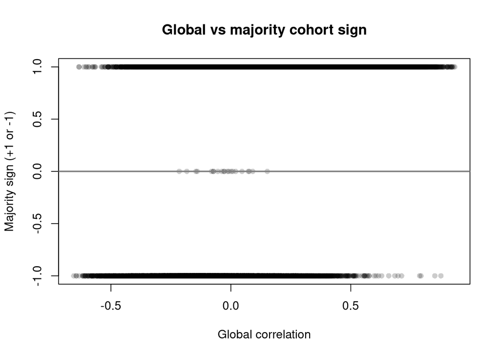

Figure 1 : Global correlation vs majority cohort sign (subset).

```r
majSignNum <- majoritySign
plot(coco, majSignNum, pch = 16, col = rgb(0, 0, 0, 0.2),
     xlab = "Global correlation", ylab = "Majority sign (+1 or -1)",
     main = "Global vs majority cohort sign")
abline(h = 0, lwd = 2, col = "gray50")
```

Pairs near the extremes of global correlation still show majority signs that can be opposite, reinforcing the Simpson-style effect.

# Conclusions

In a high-variance subset (1000 genes × 50 miRs), a meaningful fraction of pairs show global sign disagreement with the cohort majority, and the rate remains sizable even for strong global correlations. This provides a concise, quantitative main-text summary of context dependence.